# Laboratory of Consumer and Business Analytics

Conjoint analysis - Laptop Dataset

Nisha Antony

Sander Martins

27/01/2021

# Agenda

- Project Description
- Summary of all the analysis to be presented
- Dataset description
- Dataset balanced and Association of attributes
- Models to fit our data
- Choosing models part 1
- Are our users homogeneous?
- Correlated models
- Choosing models part 2
- Preference share of the users
- Product profiles
- Conclusion

## Project Description

The objective of this project is to have an understanding of conjoint analysis and demonstrate some of the conclusion that we be can found using this analysis. In this project, we will analyze the preferences of an individual while purchasing a laptop. When it comes to laptops, we have several options in the market. A customer usually does a thorough research before he/she makes the purchase. The final decision depends on several attributes of the product and its relevance to the customer. We study the relationship between the choice and product attributes.

## Dataset description

Our dataset represents the generated answers to questionnaires regarding the choice of laptops. It is represented in a long format, in other words, we have a row for each alternatives. We have 4 alternatives each for 7500 questions and 4 levels for each attributes.

```
##     resp.id            ques      alt      Price        RAM         Memory
##  Min.   :  1.00   Min.   :   1   1:7500   0.7:7516   4GB :7582   126GB:7432
##  1st Qu.: 75.75   1st Qu.:1876   2:7500   1  :7411   8GB :7319   256GB:7596
##  Median :150.50   Median :3750   3:7500   1.5:7545   16GB:7609   512GB:7524
##  Mean   :150.50   Mean   :3750   4:7500   2  :7528   32GB:7490   1T   :7448
##  3rd Qu.:225.25   3rd Qu.:5625
##  Max.   :300.00   Max.   :7500
##  Processor   Weight     ScreenSize     choice
##  i3:7491   0.8kg:7464   12:7584    Min.   :0.00
##  i5:7580   1kg  :7372   13:7487    1st Qu.:0.00
##  i7:7352   1.2kg:7584   14:7509    Median :0.00
##  i9:7577   1.5kg:7580   16:7420    Mean   :0.25
##                                    3rd Qu.:0.25
##                                    Max.   :1.00
```

## Dataset balanced and Association of attributes

In this part, we check whether the attributes are well balanced.

```
##
##  0.7    1  1.5    2
## 7516 7411 7545 7528
```

```
##
##  4GB  8GB 16GB 32GB
## 7582 7319 7609 7490
```

```
##
## 126GB 256GB 512GB    1T
##  7432  7596  7524  7448
```

```
##
##   i3   i5   i7   i9
## 7491 7580 7352 7577
```

```
##
## 0.8kg   1kg 1.2kg 1.5kg
##  7464  7372  7584  7580
```

```
##
##   12   13   14   16
## 7584 7487 7509 7420
```

Here, the attributes are properly balanced, which means that the frequencies across each levels of the attributes are equally distributed. There is no over/under representation in level of attributes.

Now we can look into the association of attributes with choice made by the respondent. The xtabs() which provides the joint distribution between two variables is used here.

```r
xtabs(choice ~ Price, data=laptops)
```

```
## Price
##  0.7    1  1.5    2
## 2338 1895 1773 1494
```

```r
xtabs(choice ~ RAM, data=laptops)
```

```
## RAM
##  4GB  8GB 16GB 32GB
## 1988 2865 1347 1300
```

```r
xtabs(choice ~ Memory, data=laptops)
```

```
## Memory
## 126GB 256GB 512GB    1T
##  2043  1127  1153  3177
```

```r
xtabs(choice ~ Processor, data=laptops)
```

```
## Processor
##   i3   i5   i7   i9
## 2121 2329 1861 1189
```

```r
xtabs(choice ~ Weight, data=laptops)
```

```
## Weight
## 0.8kg   1kg 1.2kg 1.5kg
##  1490  2203  2424  1383
```

```r
xtabs(choice ~ ScreenSize, data=laptops)
```

```
## ScreenSize
##   12   13   14   16
##  838 1644 2496 2522
```

From the joint distribution obtained, we can see that the customers highly prefer laptops with bigger screensize, high memory, a decent RAM of 8GB and i5 processor and are looking for products mostly at price range of 0.7K to 1K. It is also in interesting to see that laptops with 126GB memory is the second popular on after 1TB. Very few are opting for laptops with 12" screen or are interested in spending 2K on a laptop.

## Models to fit our data

### Multinomial Logit Model(MNL)

From the dataset, we can gather that the respondent had 4 alternatives to make his/her final choice; implying that the dependent variable is a qualitative multinomial variable with 4 levels. Multinomial Logit model (MNL) is an appropriate one to fit this kind of data. MNL gives the measurement of association between each attributes and respondent choice.

We use mlogit() function to fit the MNL model. However, the function requires us to organize the data in a special format by using dfidx().

Now, we assess how attributes affects the choice. In the first model, we will consider the intercept parameters so that we can test the restrictions on them by comparing two models.

```r
lm1 <- mlogit(choice ~ Price + RAM + Memory + Processor + Weight + ScreenSize , data = laptops.mlogit)
summary(lm1)
```

```
##
## Call:
## mlogit(formula = choice ~ Price + RAM + Memory + Processor +
##     Weight + ScreenSize, data = laptops.mlogit, method = "nr")
##
## Frequencies of alternatives:choice
##       1       2       3       4
## 0.24573 0.25267 0.25227 0.24933
##
## nr method
## 6 iterations, 0h:0m:2s
## g'(-H)^-1g = 2.15E-06
## successive function values within tolerance limits
##
## Coefficients :
##                Estimate Std. Error  z-value  Pr(>|z|)
## (Intercept):2  0.045634   0.040334   1.1314 0.2578870
## (Intercept):3  0.058009   0.040377   1.4367 0.1508084
## (Intercept):4  0.032013   0.040412   0.7922 0.4282674
## Price1        -0.446694   0.045273  -9.8667 < 2.2e-16 ***
## Price1.5      -0.571078   0.045618 -12.5186 < 2.2e-16 ***
## Price2        -0.953224   0.047344 -20.1338 < 2.2e-16 ***
## RAM8GB         0.924216   0.044407  20.8124 < 2.2e-16 ***
## RAM16GB       -0.690506   0.047911 -14.4122 < 2.2e-16 ***
## RAM32GB       -0.813077   0.048592 -16.7326 < 2.2e-16 ***
## Memory256GB   -1.088881   0.049437 -22.0258 < 2.2e-16 ***
## Memory512GB   -1.003092   0.048926 -20.5021 < 2.2e-16 ***
## Memory1T       1.027503   0.043944  23.3822 < 2.2e-16 ***
## Processori5    0.190759   0.043949   4.3405 1.421e-05 ***
## Processori7   -0.185945   0.045471  -4.0893 4.327e-05 ***
## Processori9   -1.113779   0.050210 -22.1825 < 2.2e-16 ***
## Weight1kg      0.767455   0.047487  16.1615 < 2.2e-16 ***
## Weight1.2kg    0.942015   0.047594  19.7926 < 2.2e-16 ***
## Weight1.5kg   -0.175095   0.050035  -3.4994 0.0004663 ***
## ScreenSize13   1.124687   0.054422  20.6660 < 2.2e-16 ***
## ScreenSize14   1.932395   0.054466  35.4788 < 2.2e-16 ***
## ScreenSize16   2.007688   0.054852  36.6019 < 2.2e-16 ***
## ---
## Signif. codes:  0 '***' 0.001 '**' 0.01 '*' 0.05 '.' 0.1 ' ' 1
##
## Log-Likelihood: -6750.6
## McFadden R^2:  0.3507
## Likelihood ratio test : chisq = 7292.3 (p.value = < 2.22e-16)
```

The models output have several parameters and values similar to binomial logit model. The *Estimate* column provides the estimated average part worths for each level; they have to be interpreted with respect to the reference level of each attribute.

In the summary of lm1 model, we can see that the model estimate coefficient of RAM8GB, RAM16GB and RAM32GB with respect to RAM4GB laptops measuring the preference. The laptops with 8GB RAM are more preferred than RAM of 4GB(which is the reference level) whereas RAM of 32GB and 16GB has negative sign, which indicates that customers were less attracted to those when compared to our reference level. Similarly, in terms of memory the coefficients are estimated with respect to Memory126GB. In this case, laptops with 1TB memory has higher preference compared to 126GB. When it comes to processors, i3 is taken as the reference value and from the est. coefficient, we can see that i5 is more preferred. The 12-inch and 0.7k is the reference point for screensize and price respectively. Among those attributes, we can see that 16 inch models are far more preferred with respect to 12 inch ones and for the price range, 0.7k itself is most preferred. The est. intercepts provide the preferences for the positions of the alternatives in each question. Here the values corresponding to those intercepts are very small implying that position of alternatives doesn’t have much significance.

### Multinomial Logit Model(MNL) Without Intercept

In order to formally test the significance of the intercept, we fit another model without the intercept parameters and perform a likelihood ratio test comparing both models.

```r
lm2 <- mlogit(choice ~ Price + RAM + Memory + Processor + Weight + ScreenSize | -1, data = laptops.mlogit)
summary(lm2)
```

```
##
## Call:
## mlogit(formula = choice ~ Price + RAM + Memory + Processor +
##     Weight + ScreenSize | -1, data = laptops.mlogit, method = "nr")
##
## Frequencies of alternatives:choice
##       1       2       3       4
## 0.24573 0.25267 0.25227 0.24933
##
## nr method
## 6 iterations, 0h:0m:1s
## g'(-H)^-1g = 2.11E-06
## successive function values within tolerance limits
##
## Coefficients :
##               Estimate Std. Error  z-value  Pr(>|z|)
## Price1       -0.446283   0.045266  -9.8591 < 2.2e-16 ***
## Price1.5     -0.571655   0.045612 -12.5331 < 2.2e-16 ***
## Price2       -0.953178   0.047342 -20.1337 < 2.2e-16 ***
## RAM8GB        0.923871   0.044399  20.8084 < 2.2e-16 ***
## RAM16GB      -0.689757   0.047904 -14.3989 < 2.2e-16 ***
## RAM32GB      -0.812848   0.048587 -16.7296 < 2.2e-16 ***
## Memory256GB  -1.088117   0.049424 -22.0160 < 2.2e-16 ***
## Memory512GB  -1.002787   0.048897 -20.5082 < 2.2e-16 ***
## Memory1T      1.027356   0.043936  23.3829 < 2.2e-16 ***
## Processori5   0.190622   0.043945   4.3377 1.440e-05 ***
## Processori7  -0.185582   0.045461  -4.0822 4.461e-05 ***
## Processori9  -1.113668   0.050205 -22.1823 < 2.2e-16 ***
## Weight1kg     0.767671   0.047483  16.1673 < 2.2e-16 ***
## Weight1.2kg   0.942085   0.047585  19.7978 < 2.2e-16 ***
## Weight1.5kg  -0.174588   0.050011  -3.4910 0.0004813 ***
## ScreenSize13  1.123946   0.054412  20.6561 < 2.2e-16 ***
## ScreenSize14  1.931256   0.054448  35.4697 < 2.2e-16 ***
## ScreenSize16  2.006770   0.054839  36.5938 < 2.2e-16 ***
## ---
## Signif. codes:  0 '***' 0.001 '**' 0.01 '*' 0.05 '.' 0.1 ' ' 1
##
## Log-Likelihood: -6751.7
```

### Choosing models part 1

```
## Likelihood ratio test
##
## Model 1: choice ~ Price + RAM + Memory + Processor + Weight + ScreenSize
## Model 2: choice ~ Price + RAM + Memory + Processor + Weight + ScreenSize |
##     -1
##   #Df  LogLik Df Chisq Pr(>Chisq)
## 1  21 -6750.6
## 2  18 -6751.7 -3 2.296     0.5133
```

Here we compare the MNL model with and without estimated intercepts. The comparison between the lm1 and the lm2 with no intercepts leads to a p-value of 0.5133. Since we have a high p-value (in comparison with significance level 0.05), we can conclude that the two models are not significantly different in terms of goodness of fit. This indicates that the alternative specific constants are not necessary to adequately model the data.

## Profiles and preference share

### Popular profiles (top 15)

From the survey dataset, we now try to extract the most popular laptop models using a frequency table.

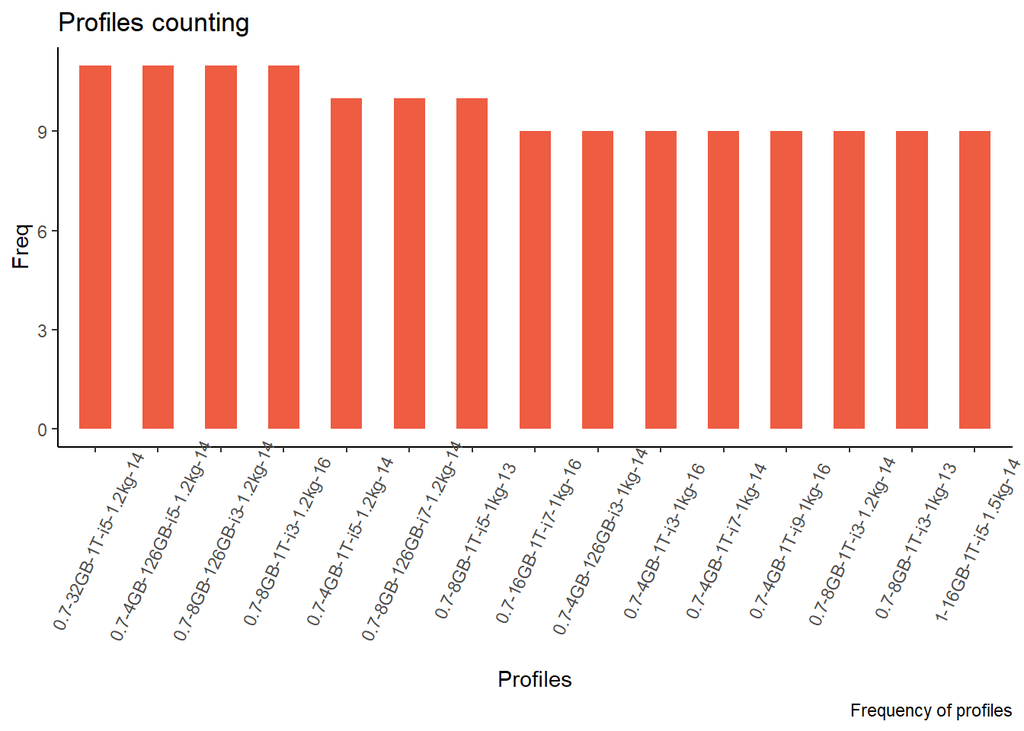

The graph above shows the top 15 popular profiles in the dataset. As we can see most of them are in the price range 0.7k with RAM and memory variants(4GB, 8GB in most cases and 126GB and 1TB respectively).

Next step is to create a subset of designs for which we predict the preference shares. In order to do that, we initially create a set of all possible designs. From these possible designs we select a set of profiles for further studying them.

### Profiles chosen

The profiles are chosen based on 3 market levels: entry, mid-range and high performance.

```
##    Price  RAM Memory Processor Weight ScreenSize
## 1      1  8GB  256GB        i5    1kg         13
## 2    0.7  4GB  126GB        i3  0.8kg         12
## 3      1  4GB  126GB        i3  1.2kg         13
## 4    0.7  8GB  126GB        i3  1.2kg         14
## 5    0.7  8GB     1T        i3  1.2kg         16
## 6    1.5 16GB  512GB        i7  1.5kg         16
## 7    0.7  4GB  126GB        i5  1.2kg         14
## 8      2 16GB  512GB        i7  1.2kg         16
## 9      2 32GB     1T        i9  1.5kg         14
## 10   0.7  4GB     1T        i9    1kg         16
```

Now that we have chosen the profiles, we create a function to predict the preference shares for the profiles with the estimated model.

## Preference share prediction (MNL)

```
##          share Price  RAM Memory Processor Weight ScreenSize
## 1  0.019110330     1  8GB  256GB        i5    1kg         13
## 2  0.004386443   0.7  4GB  126GB        i3  0.8kg         12
## 3  0.022159508     1  4GB  126GB        i3  1.2kg         13
## 4  0.195533286   0.7  8GB  126GB        i3  1.2kg         14
## 5  0.589102805   0.7  8GB     1T        i3  1.2kg         16
## 6  0.002365335   1.5 16GB  512GB        i7  1.5kg         16
## 7  0.093923556   0.7  4GB  126GB        i5  1.2kg         14
## 8  0.004933601     2 16GB  512GB        i7  1.2kg         16
## 9  0.003986239     2 32GB     1T        i9  1.5kg         14
## 10 0.064498897   0.7  4GB     1T        i9    1kg         16
```

We can further study the impact of variations in the level of attributes by creating a preference share-sensitivity chart. This provides useful indications to the people that have made the design as they get a clear intuitive picture of how changes in the design influence the preference share.

```r
source("BootCI.predict.mnl.R")
```

This function is to obtain the Bootstrap Confidence Intervals, it will re-estimate the models and calculate the preference share several times. Here we estimate the model for random samples and obtain the values estimated corresponding to each parameters. From this we will obtain the bootstrap distribution from which we can get the CI. The function takes model(which should be used to compute preference share), chosen set of profiles. Among these chosen profiles, the first one will be our profile, which is to be assessed while comparing with other products that dominates the market. In short, we are trying to find the preference share of our profile in comparison with other product profiles. By default the function as 500 simulations with 95% CI. So this function will return the preference shares along with the bootstrap CI corresponding to each profiles.

### Preference share with bootstrap - Fixed model

```
##          share        2.5%       97.5% Price  RAM Memory Processor Weight
## 1  0.019110330 0.015708019 0.022678844     1  8GB  256GB        i5    1kg
## 2  0.004386443 0.003673657 0.005283065   0.7  4GB  126GB        i3  0.8kg
## 3  0.022159508 0.019112507 0.025401749     1  4GB  126GB        i3  1.2kg
## 4  0.195533286 0.178486367 0.211859819   0.7  8GB  126GB        i3  1.2kg
## 5  0.589102805 0.558379519 0.616442787   0.7  8GB     1T        i3  1.2kg
## 6  0.002365335 0.001887967 0.002904350   1.5 16GB  512GB        i7  1.5kg
## 7  0.093923556 0.082309098 0.107514901   0.7  4GB  126GB        i5  1.2kg
## 8  0.004933601 0.004055373 0.005910233     2 16GB  512GB        i7  1.2kg
## 9  0.003986239 0.003266331 0.004840205     2 32GB     1T        i9  1.5kg
## 10 0.064498897 0.055879466 0.074163121   0.7  4GB     1T        i9    1kg
##    ScreenSize
## 1          13
## 2          12
## 3          13
## 4          14
## 5          16
## 6          16
## 7          14
## 8          16
## 9          14
## 10         16
```

Preference share is a parameter that help us to understand which profiles are appreciated more by the customers. It can also be used to analyze the importance of attributes. We perform sensitivity analysis to study the attributes; how preference share is affected by the variations in the attributes.

The preference shares are in logit scale it difficult to interpret it. Thus we use sensitivity analysis by studying how preference share changes as each level of each attributes are changed one after the other. This function intakes the model, attributes, reference profile: one which is used to study the sensitivity of attributes and competitive set of profiles as the input.

### Trade-off attributes graph - MNL

```
##             level       share     increase
## Price1        0.7 0.029542219  0.010431890
## Price2          1 0.019110330  0.000000000
## Price3        1.5 0.016896592 -0.002213738
## Price4          2 0.011599503 -0.007510826
## RAM1          4GB 0.007674851 -0.011435478
## RAM2          8GB 0.019110330  0.000000000
## RAM3         16GB 0.003865238 -0.015245092
## RAM4         32GB 0.003419110 -0.015691220
## Memory1     126GB 0.054675411  0.035565082
## Memory2     256GB 0.019110330  0.000000000
## Memory3     512GB 0.020777229  0.001666899
## Memory4        1T 0.139103221  0.119992891
## Processor1     i3 0.015846199 -0.003264131
## Processor2     i5 0.019110330  0.000000000
## Processor3     i7 0.013197605 -0.005912724
## Processor4     i9 0.005259109 -0.013851221
## Weight1     0.8kg 0.008960730 -0.010149599
## Weight2       1kg 0.019110330  0.000000000
## Weight3     1.2kg 0.022669210  0.003558880
## Weight4     1.5kg 0.007536066 -0.011574264
## ScreenSize1    12 0.006291918 -0.012818411
## ScreenSize2    13 0.019110330  0.000000000
## ScreenSize3    14 0.041849643  0.022739313
## ScreenSize4    16 0.044984600  0.025874270
```

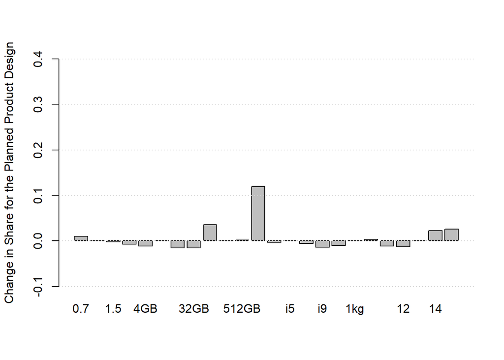

## Are users homogeneous?

Now we are going to fit mixed MNL model, where the coefficients vary randomly over respondents in the population, rather than being fixed. To estimate a multinomial logit model with random coefficients using “mlogit”, we define a vector indicating which coefficients should vary across customers.

The mlogit() requires a character vector the same length as the coefficient vector with a letter code indicating the distribution that random coefficients should follow across the respondents: “n” for normal, “l” for log normal, “t” for truncated normal, and “u” for uniform. For this analysis, we assume that all the coefficients are normally distributed across the population and call our vector “lm2.rpar”.

### Mixed MNL (with Random Effect)

In order to verify that, we are going to create a model that takes in consideration random effects (variation according to respondents).

```r
lm2.mixed <- mlogit(choice ~ Price + RAM + Memory + Processor + Weight + ScreenSize  | -1,
                   data = laptops.mlogit,
                   panel=TRUE, rpar = lm2.rpar, correlation = FALSE)
summary(lm2.mixed)
```

```
##
## Call:
## mlogit(formula = choice ~ Price + RAM + Memory + Processor +
##     Weight + ScreenSize | -1, data = laptops.mlogit, rpar = lm2.rpar,
##     correlation = FALSE, panel = TRUE)
##
## Frequencies of alternatives:choice
##       1       2       3       4
## 0.24573 0.25267 0.25227 0.24933
##
## bfgs method
## 31 iterations, 0h:1m:3s
## g'(-H)^-1g = 1.14E-07
## gradient close to zero
##
## Coefficients :
##                  Estimate Std. Error  z-value  Pr(>|z|)
## Price1          -0.513206   0.050625 -10.1373 < 2.2e-16 ***
## Price1.5        -0.636052   0.051639 -12.3173 < 2.2e-16 ***
## Price2          -1.102139   0.054235 -20.3215 < 2.2e-16 ***
## RAM8GB           1.086620   0.050751  21.4107 < 2.2e-16 ***
## RAM16GB         -0.823429   0.056087 -14.6813 < 2.2e-16 ***
## RAM32GB         -0.921903   0.054573 -16.8929 < 2.2e-16 ***
## Memory256GB     -1.294880   0.056797 -22.7983 < 2.2e-16 ***
## Memory512GB     -1.216042   0.056786 -21.4145 < 2.2e-16 ***
## Memory1T         1.198006   0.051026  23.4781 < 2.2e-16 ***
## Processori5      0.197380   0.049440   3.9923 6.544e-05 ***
## Processori7     -0.223364   0.049995  -4.4677 7.906e-06 ***
## Processori9     -1.348028   0.057457 -23.4615 < 2.2e-16 ***
## Weight1kg        0.849019   0.054442  15.5950 < 2.2e-16 ***
## Weight1.2kg      1.080796   0.054020  20.0073 < 2.2e-16 ***
## Weight1.5kg     -0.204326   0.055704  -3.6681 0.0002444 ***
## ScreenSize13     1.299412   0.061869  21.0026 < 2.2e-16 ***
## ScreenSize14     2.200346   0.064643  34.0383 < 2.2e-16 ***
## ScreenSize16     2.332517   0.064499  36.1634 < 2.2e-16 ***
## sd.Price1       -0.454341   0.059929  -7.5813 3.419e-14 ***
## sd.Price1.5      0.682943   0.056733  12.0378 < 2.2e-16 ***
## sd.Price2        0.274326   0.062423   4.3946 1.110e-05 ***
## sd.RAM8GB       -0.027677   0.067640  -0.4092 0.6824128
## sd.RAM16GB       0.572349   0.069340   8.2542 2.220e-16 ***
```

[output cut: 23 more lines]

```
## RAM8GB       -Inf  1.0679522  1.0866197  1.0866197  1.10528728  Inf
## RAM16GB      -Inf -1.2094721 -0.8234287 -0.8234287 -0.43738531  Inf
## RAM32GB      -Inf -1.0277623 -0.9219033 -0.9219033 -0.81604444  Inf
## Memory256GB  -Inf -1.5641748 -1.2948803 -1.2948803 -1.02558567  Inf
## Memory512GB  -Inf -1.4780041 -1.2160421 -1.2160421 -0.95407999  Inf
## Memory1T     -Inf  1.0978769  1.1980059  1.1980059  1.29813498  Inf
## Processori5  -Inf -0.2793257  0.1973797  0.1973797  0.67408514  Inf
## Processori7  -Inf -0.4292685 -0.2233641 -0.2233641 -0.01745963  Inf
## Processori9  -Inf -1.6434746 -1.3480284 -1.3480284 -1.05258225  Inf
## Weight1kg    -Inf  0.4405982  0.8490192  0.8490192  1.25744022  Inf
## Weight1.2kg  -Inf  0.7876098  1.0807961  1.0807961  1.37398247  Inf
## Weight1.5kg  -Inf -0.4372061 -0.2043261 -0.2043261  0.02855392  Inf
## ScreenSize13 -Inf  1.2019834  1.2994124  1.2994124  1.39684141  Inf
## ScreenSize14 -Inf  1.6305741  2.2003463  2.2003463  2.77011846  Inf
## ScreenSize16 -Inf  2.2697799  2.3325170  2.3325170  2.39525412  Inf
```

```r
# summary(lm2.mixed)$CoefTable[summary(lm2.mixed)$CoefTable[,4]<=0.05, ]
```

In mixed MNL framework, we get a distribution of respondent level values of a parameter for which we can compute the mean and the variance. So we compute 2 parameters to each attributes: we compute the mean and variance corresponding to each distribution respondent variables. In summary, we can see the estimate of mean and std. deviation corresponding to the distribution of each attributes.

By analyzing the std. deviation, we get the level of variability in customer preference. Higher the est. std. deviation, higher the heterogeneity in the customer preference. The std. deviation can be interpreted by comparing it with our est. mean value. If the absolute std deviation is greater than the absolute mean, we can say we have relevant heterogeneity in consumer preference. Higher the difference between the absolute values, stronger the relevance of heterogeneity.

In the second table, gives the summary of distribution. If the sign remains the same across all the quantiles, then it indicates that we have a substantial homogeneity in the preferences. Here, the parameters “Weight1.5kg” and “Processori5” has a different signs across the quantiles implying substantial heterogeneity. The other parameters are homogeneous across the quantiles indicating the customer preference in those attributes are homogeneous.

### Analysing heterogeneity

By comparing the sign of the quantiles we can identify that Processori5 and Weight1.5kg have different signs, which could imply heterogeneity in the customer preferences.

```
##       Min.    1st Qu.     Median       Mean    3rd Qu.       Max.
##       -Inf -0.2793257  0.1973797  0.1973797  0.6740851        Inf
```

```
##        Min.     1st Qu.      Median        Mean     3rd Qu.        Max.
##        -Inf -0.43720609 -0.20432608 -0.20432608  0.02855392         Inf
```

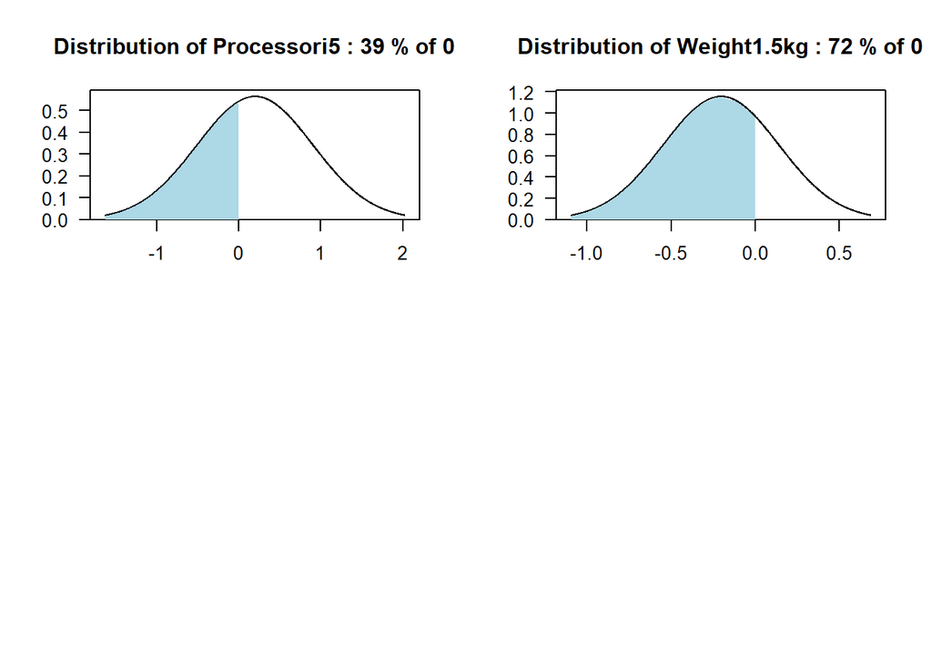

```r
par(mfrow=c(2,2))
plot(processor5.distr)
plot(Weight1.5kg.distr)
```

### Correlated model

It is reasonable to think that some variables can be correlated. In order to verify that, we are going to create a model that takes in consideration random effects (variation according to respondents) and that the random parameters are correlated. First we consider correlation among all pair of variables and analyze the signals of the random coefficients.

```r
lm2.mixed2 <- update(lm2.mixed, correlation = TRUE)
# summary(lm2.mixed2)
# summary(lm2.mixed2)$CoefTable[summary(lm2.mixed2)$CoefTable[,4]<=0.05, ]
```

```r
cov2cor(cov.mlogit(lm2.mixed2))
```

```
##                   Price1     Price1.5      Price2      RAM8GB      RAM16GB
## Price1        1.00000000 -0.687044183  0.33407312  0.10860838 -0.677357177
## Price1.5     -0.68704418  1.000000000 -0.36500435 -0.23164414 -0.001964564
## Price2        0.33407312 -0.365004352  1.00000000  0.15467773 -0.294073314
## RAM8GB        0.10860838 -0.231644138  0.15467773  1.00000000 -0.063199056
## RAM16GB      -0.67735718 -0.001964564 -0.29407331 -0.06319906  1.000000000
## RAM32GB       0.46400413 -0.250924657 -0.41191224  0.58451759 -0.319788258
## Memory256GB   0.54616025 -0.263727489 -0.04810343 -0.45817795 -0.198857976
## Memory512GB  -0.05506315  0.332139778 -0.26754143  0.41610824 -0.089702311
## Memory1T      0.23276658  0.098201829  0.27091114  0.15185407 -0.561025286
## Processori5  -0.17805894  0.111847564  0.18037118  0.62353224  0.023223852
## Processori7   0.15460179  0.045719359 -0.05725477 -0.64296668 -0.218732488
## Processori9   0.07820549 -0.391136495 -0.03158962  0.11129423  0.155902361
## Weight1kg     0.08106111 -0.183853198 -0.22650865  0.19118618  0.058105201
## Weight1.2kg   0.09313598 -0.045269600 -0.05639516 -0.14205431 -0.098547700
## Weight1.5kg   0.30890447 -0.199620366  0.04581885  0.21571613 -0.181654394
## ScreenSize13 -0.25736456  0.321899644 -0.33426606 -0.18742088  0.032521362
## ScreenSize14 -0.02437966  0.136258460  0.05543439 -0.27442235 -0.174163582
## ScreenSize16  0.04344272  0.217397414 -0.35305377 -0.12307525 -0.252440381
##                   RAM32GB  Memory256GB Memory512GB    Memory1T Processori5
## Price1        0.464004127  0.546160255 -0.05506315  0.23276658 -0.17805894
## Price1.5     -0.250924657 -0.263727489  0.33213978  0.09820183  0.11184756
## Price2       -0.411912244 -0.048103429 -0.26754143  0.27091114  0.18037118
## RAM8GB        0.584517595 -0.458177954  0.41610824  0.15185407  0.62353224
## RAM16GB      -0.319788258 -0.198857976 -0.08970231 -0.56102529  0.02322385
## RAM32GB       1.000000000  0.110412027  0.43191445  0.08346486  0.15483224
## Memory256GB   0.110412027  1.000000000  0.18894946 -0.17917021 -0.43976112
## Memory512GB   0.431914454  0.188949459  1.00000000  0.14537213  0.19834397
## Memory1T      0.083464856 -0.179170211  0.14537213  1.00000000 -0.08485591
## Processori5   0.154832239 -0.439761119  0.19834397 -0.08485591  1.00000000
## Processori7  -0.257926949  0.287672895 -0.35714155  0.31805327 -0.50978621
## Processori9   0.127012238 -0.265963580 -0.41921447  0.03922100  0.04411079
## Weight1kg     0.305480336 -0.106481865  0.05597285 -0.09863609 -0.25854741
## Weight1.2kg  -0.001826036  0.007056886 -0.31595760 -0.03504469  0.12162371
## Weight1.5kg   0.309079167  0.213244822  0.29129634  0.21259665 -0.10164774
## ScreenSize13 -0.019671256 -0.176461482 -0.13847219 -0.33144333 -0.02504435
## ScreenSize14 -0.244955118 -0.113184270 -0.31753787 -0.20517453 -0.13949621
## ScreenSize16  0.233715215 -0.007231263 -0.03945633 -0.19865984 -0.05212333
##              Processori7 Processori9   Weight1kg  Weight1.2kg Weight1.5kg
## Price1        0.15460179  0.07820549  0.08106111  0.093135976  0.30890447
```

[output cut: 21 more lines]

```
## RAM8GB        -0.18742088  -0.27442235 -0.123075252
## RAM16GB        0.03252136  -0.17416358 -0.252440381
## RAM32GB       -0.01967126  -0.24495512  0.233715215
## Memory256GB   -0.17646148  -0.11318427 -0.007231263
## Memory512GB   -0.13847219  -0.31753787 -0.039456334
## Memory1T      -0.33144333  -0.20517453 -0.198659840
## Processori5   -0.02504435  -0.13949621 -0.052123326
## Processori7   -0.05992128   0.05057417  0.054628592
## Processori9    0.21367891   0.01517149  0.213037394
## Weight1kg      0.10081021   0.14488302  0.192064565
## Weight1.2kg   -0.14738383   0.16235937  0.042563413
## Weight1.5kg   -0.03505430   0.21449723  0.136057703
## ScreenSize13   1.00000000   0.57610061  0.820028899
## ScreenSize14   0.57610061   1.00000000  0.507964027
## ScreenSize16   0.82002890   0.50796403  1.000000000
```

```r
summary(vcov(lm2.mixed2, what = "rpar", type = "cor"))
```

```
##                                 Estimate Std. Error z-value  Pr(>|z|)
## sd.Price1                      0.1046453  0.0608098  1.7209  0.085276 .
## sd.Price1.5                    0.7411276  0.0584025 12.6900 < 2.2e-16 ***
## sd.Price2                      0.0937927  0.0601420  1.5595  0.118873
## sd.RAM8GB                      0.1820812  0.0645132  2.8224  0.004767 **
## sd.RAM16GB                     0.6106933  0.0709156  8.6115 < 2.2e-16 ***
## sd.RAM32GB                     0.3645901  0.0718506  5.0743 3.890e-07 ***
## sd.Memory256GB                 0.4626757  0.0663338  6.9750 3.060e-12 ***
## sd.Memory512GB                 0.5651760  0.0696229  8.1177 4.752e-16 ***
## sd.Memory1T                    0.3757116  0.0627030  5.9919 2.074e-09 ***
## sd.Processori5                 0.6234412  0.0640201  9.7382 < 2.2e-16 ***
## sd.Processori7                 0.6200873  0.0637963  9.7198 < 2.2e-16 ***
## sd.Processori9                 0.9480850  0.0777781 12.1896 < 2.2e-16 ***
## sd.Weight1kg                   0.8521610  0.0723369 11.7805 < 2.2e-16 ***
## sd.Weight1.2kg                 0.7387702  0.0726530 10.1685 < 2.2e-16 ***
## sd.Weight1.5kg                 0.6769665  0.0686354  9.8632 < 2.2e-16 ***
## sd.ScreenSize13                0.7546049  0.0821778  9.1826 < 2.2e-16 ***
## sd.ScreenSize14                1.2494894  0.0786599 15.8847 < 2.2e-16 ***
## sd.ScreenSize16                0.9314969  0.0814374 11.4382 < 2.2e-16 ***
## cor.Price1:Price1.5           -0.6870442  0.6372867 -1.0781  0.280999
## cor.Price1:Price2              0.3340731  0.7125909  0.4688  0.639202
## cor.Price1.5:Price2           -0.3650044  0.7402928 -0.4931  0.621974
## cor.Price1:RAM8GB              0.1086084  0.7123676  0.1525  0.878823
## cor.Price1.5:RAM8GB           -0.2316441  0.4866664 -0.4760  0.634088
## cor.Price2:RAM8GB              0.1546777  0.7451379  0.2076  0.835555
## cor.Price1:RAM16GB            -0.6773572  0.9135783 -0.7414  0.458431
## cor.Price1.5:RAM16GB          -0.0019646  0.1785798 -0.0110  0.991223
## cor.Price2:RAM16GB            -0.2940733  1.0264361 -0.2865  0.774496
## cor.RAM8GB:RAM16GB            -0.0631991  0.4367045 -0.1447  0.884933
## cor.Price1:RAM32GB             0.4640041  0.6203368  0.7480  0.454468
## cor.Price1.5:RAM32GB          -0.2509247  0.2768118 -0.9065  0.364681
## cor.Price2:RAM32GB            -0.4119122  1.0179386 -0.4047  0.685732
## cor.RAM8GB:RAM32GB             0.5845176  0.3288016  1.7777  0.075450 .
## cor.RAM16GB:RAM32GB           -0.3197883  0.2850313 -1.1219  0.261888
## cor.Price1:Memory256GB         0.5461603  0.6041802  0.9040  0.366012
## cor.Price1.5:Memory256GB      -0.2637275  0.2379968 -1.1081  0.267813
## cor.Price2:Memory256GB        -0.0481034  0.8306166 -0.0579  0.953818
## cor.RAM8GB:Memory256GB        -0.4581780  0.5983102 -0.7658  0.443803
## cor.RAM16GB:Memory256GB       -0.1988580  0.2911282 -0.6831  0.494569
## cor.RAM32GB:Memory256GB        0.1104120  0.3185830  0.3466  0.728913
```

[output cut: 119 more lines]

```
## cor.RAM16GB:ScreenSize16      -0.2524404  0.2245690 -1.1241  0.260966
## cor.RAM32GB:ScreenSize16       0.2337152  0.2329983  1.0031  0.315824
## cor.Memory256GB:ScreenSize16  -0.0072313  0.2151751 -0.0336  0.973191
## cor.Memory512GB:ScreenSize16  -0.0394563  0.2058139 -0.1917  0.847970
## cor.Memory1T:ScreenSize16     -0.1986598  0.2785827 -0.7131  0.475778
## cor.Processori5:ScreenSize16  -0.0521233  0.2024691 -0.2574  0.796840
## cor.Processori7:ScreenSize16   0.0546286  0.1901970  0.2872  0.773943
## cor.Processori9:ScreenSize16   0.2130374  0.1392787  1.5296  0.126122
## cor.Weight1kg:ScreenSize16     0.1920646  0.1393485  1.3783  0.168109
## cor.Weight1.2kg:ScreenSize16   0.0425634  0.1739966  0.2446  0.806749
## cor.Weight1.5kg:ScreenSize16   0.1360577  0.1768027  0.7695  0.441570
## cor.ScreenSize13:ScreenSize16  0.8200289  0.0500627 16.3800 < 2.2e-16 ***
## cor.ScreenSize14:ScreenSize16  0.5079640  0.0623374  8.1486 3.681e-16 ***
## ---
## Signif. codes:  0 '***' 0.001 '**' 0.01 '*' 0.05 '.' 0.1 ' ' 1
```

By analyzing the signs from random effect coefficients, we can update the model to contain just the variables that are correlated.

```r
lm2.mixed3 <- update(lm2.mixed2, correlation = c("Price1.5", "RAM8GB","RAM16GB", "RAM32GB", "Memory256GB","Memory512GB", "Memory1T", "Processori5", "Processori7","Processori9", "Weight1kg", "Weight1.2kg", "Weight1.5kg", "ScreenSize13", "ScreenSize14", "ScreenSize16"))
```

### Choosing models part 2

```
## Likelihood ratio test
##
## Model 1: choice ~ Price + RAM + Memory + Processor + Weight + ScreenSize |
##     -1
## Model 2: choice ~ Price + RAM + Memory + Processor + Weight + ScreenSize |
##     -1
##   #Df  LogLik Df  Chisq Pr(>Chisq)
## 1  18 -6751.7
## 2  36 -6404.9 18 693.65  < 2.2e-16 ***
## ---
## Signif. codes:  0 '***' 0.001 '**' 0.01 '*' 0.05 '.' 0.1 ' ' 1
```

Here we are compare the multinomial model with fixed attributes and the model with uncorrelated random effects. The p-value is very low (~ 0) which implies, we have enough sample evidence to reject the null hypothesis that variances with random effects are 0. That is random effects is significant in explaining consumer preferences. In this case, model that consider heterogeneity is found to be a better fit than the model that assume the homogeneity.

### Random effects but Uncorrelated vs. Random effects + all correlated

```
## Likelihood ratio test
##
## Model 1: choice ~ Price + RAM + Memory + Processor + Weight + ScreenSize |
##     -1
## Model 2: choice ~ Price + RAM + Memory + Processor + Weight + ScreenSize |
##     -1
##   #Df  LogLik  Df Chisq Pr(>Chisq)
## 1  36 -6404.9
## 2 189 -6144.3 153 521.3  < 2.2e-16 ***
## ---
## Signif. codes:  0 '***' 0.001 '**' 0.01 '*' 0.05 '.' 0.1 ' ' 1
```

Since we established that models with random effects are better fit, now we can compare the model with uncorrelated random effects with the model with all correlated random effects. From the Likelihood ratio test, we get a low p-value which implies, the random effects are not independent. The preferences of certain levels are likely associated to preferences of other levels. So we can say that, model with correlated random effects is a better fit than uncorrelated one.

### Random effects + all correlated vs. Random effects + Partially correlated

```
## Likelihood ratio test
##
## Model 1: choice ~ Price + RAM + Memory + Processor + Weight + ScreenSize |
##     -1
## Model 2: choice ~ Price + RAM + Memory + Processor + Weight + ScreenSize |
##     -1
##   #Df  LogLik  Df  Chisq Pr(>Chisq)
## 1 189 -6144.3
## 2 156 -6191.7 -33 94.812  6.887e-08 ***
## ---
## Signif. codes:  0 '***' 0.001 '**' 0.01 '*' 0.05 '.' 0.1 ' ' 1
```

The lm2.mixed2 is the multinomial model with all correlated random effects whereas lm2.mixed3 is a restricted model with some of the correlated random effects. This test is to determine whether the restricted model is better fit than the model with larger model.

We obtain a low p-value from the LR test which implies assessing consumer preferences using the model with all correlated random effects (larger model) is a better fit. So among all the models we have seen so far, lm2.mixed2 is the best model for assessing the consumer preferences.

## Preference share prediction (Mixed MNL)

Since we are using a new model, we can try to recalculate the preference in order to analyse if there is any variance.

```
##    colMeans(shares) Price  RAM Memory Processor Weight ScreenSize
## 1       0.014966821     1  8GB  256GB        i5    1kg         13
## 2       0.001889181   0.7  4GB  126GB        i3  0.8kg         12
## 3       0.010486062     1  4GB  126GB        i3  1.2kg         13
## 4       0.187527835   0.7  8GB  126GB        i3  1.2kg         14
## 5       0.626054967   0.7  8GB     1T        i3  1.2kg         16
## 6       0.001517035   1.5 16GB  512GB        i7  1.5kg         16
## 7       0.082909129   0.7  4GB  126GB        i5  1.2kg         14
## 8       0.001899564     2 16GB  512GB        i7  1.2kg         16
## 9       0.002202304     2 32GB     1T        i9  1.5kg         14
## 10      0.070547102   0.7  4GB     1T        i9    1kg         16
```

#Computing the preference share of the New Product profile

Here we are estimating the preference share of product profile with some proposed changes that can increase its acceptance rate. So our new reference profile will have an updation in the price and memory attributes, from 1K to 1.5K and 256GB to 1T respectively.

```r
proposed.profile <- ProductSelection(Price = 1.5, RAM = 8,Memory = 1,Processor = 5, Weight = 1, ScreenSize = 13)
profiles.new <- rbind(proposed.profile,entry1, entry2,entry3, entry4, mid2, mid3, high1, high2, high3)
set.seed(1234)
predict.mixed.mnl(lm2.mixed2, data=profiles.new)
```

```
##    colMeans(shares) Price  RAM Memory Processor Weight ScreenSize
## 1       0.163394122   1.5  8GB     1T        i5    1kg         13
## 2       0.001516895   0.7  4GB  126GB        i3  0.8kg         12
## 3       0.008854438     1  4GB  126GB        i3  1.2kg         13
## 4       0.163650758   0.7  8GB  126GB        i3  1.2kg         14
## 5       0.530649505   0.7  8GB     1T        i3  1.2kg         16
## 6       0.001164504   1.5 16GB  512GB        i7  1.5kg         16
## 7       0.071025080   0.7  4GB  126GB        i5  1.2kg         14
## 8       0.001641228     2 16GB  512GB        i7  1.2kg         16
## 9       0.001939126     2 32GB     1T        i9  1.5kg         14
## 10      0.056164342   0.7  4GB     1T        i9    1kg         16
```

## Conclusion

The attributes that presented properties of heterogeneity were weight (1.5) and processor (i5). The model chosen as the best representing our data was “Random effects + all correlated attributes” (lm2.mixed2).Also, the attribute that represents the biggest change in preference in relation to our selected profile was “*memory 1T*”.

One of the strategies that we could persue, if our production allows, is to increase the price from 1K to 1.5K and increase the memory from 256GB to 1T. If we use this strategy we could have a significant increase of preference share which nulifies the effect of the price increment on it. In this case, the preference share will change from ~*1.5%* to *16%*.